# Отчет по лабораторной работе №1

Компьютерный практикум по статистическому анализу данных

Дагделен Зейнап Реджеповна

1132236052@pfur.ru

Российский университет дружбы народов

2026-09-10

# Информация

## Докладчик

- Дагделен Зейнап Реджеповна
- студентка Российского университета дружбы народов
- 1132236052@pfur.ru
- г. Москва, ул. Орджоникидзе

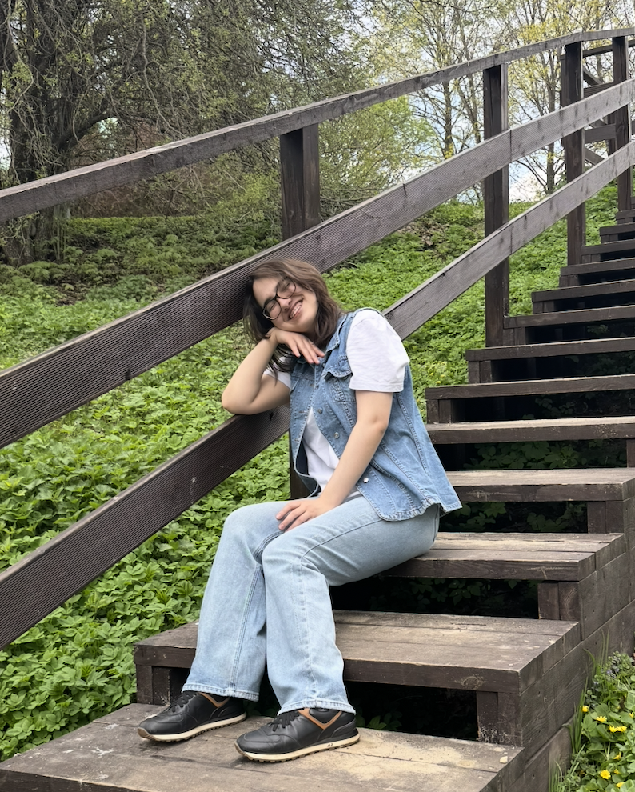

# Вводная часть

## Актуальность

- Julia — современный инструмент для научных вычислений и статистического анализа данных
- Необходимо подготовить рабочее пространство и инструментарий
- Важно познакомиться с основами синтаксиса языка на простейших примерах

## Объект и предмет исследования

- Объект: среда выполнения кода Julia (Jupyter Lab, REPL)
- Предмет: базовые синтаксические конструкции языка Julia и работа с пакетами

## Цели и задачи

- Цель:
  - Подготовить рабочее пространство и инструментарий для работы с языком программирования Julia, познакомиться с основами синтаксиса Julia на простейших примерах.
- Задачи:
  - Установить Julia, Jupyter Lab и пакет IJulia.
  - Запустить Jupyter Lab и создать новый ноутбук с ядром Julia.
  - Выполнить примеры из раздела 1.3.3 методических указаний.
  - Самостоятельно выполнить задания 1–4 по вводу/выводу, парсингу, математическим операциям и операциям с матрицами.

# Выполнение лабораторной работы

## Настройка среды: установка Julia

- Julia успешно установлена через snap и после установки проверена версия Julia

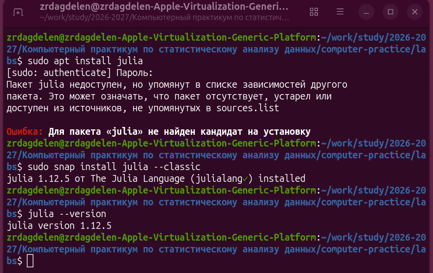

## Установка IJulia

- Запущена интерактивная оболочка Julia (julia). В ней выполнена установка пакета IJulia через Pkg

[figure not shown]

Рисунок 2: Установка IJulia через Pkg

## Запуск Jupyter Lab

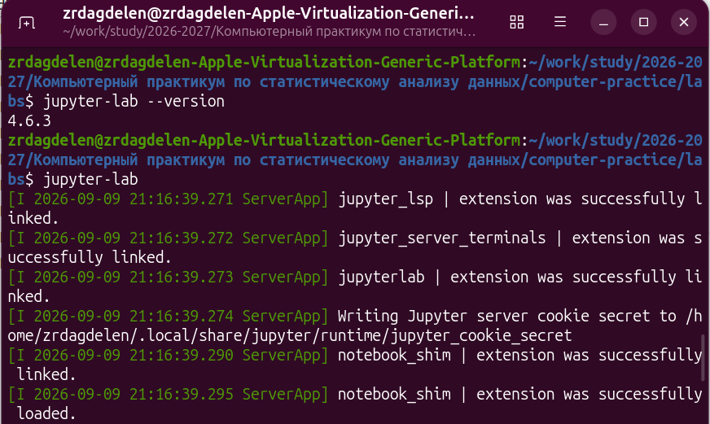

Рисунок 3: Запуск Jupyter Lab

## Интерфейс Jupyter Lab

[figure not shown]

Рисунок 4: Интерфейс Jupyter Lab с Launcher

## Выполнение примеров (раздел 1.3.3)

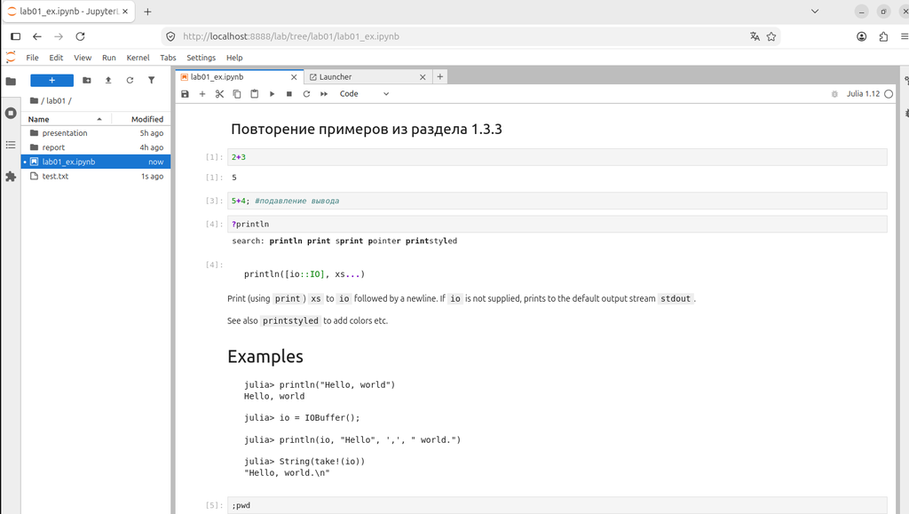

Рисунок 5: Примеры из раздела 1.3.3

## Задание 1. Функции ввода/вывода

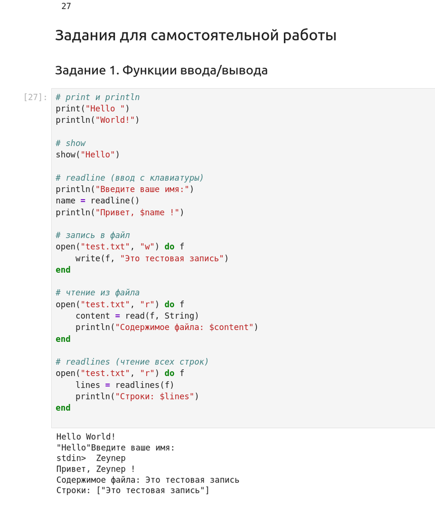

Рисунок 6: Задание 1. Ввод/вывод

## Задание 2. Функция parse()

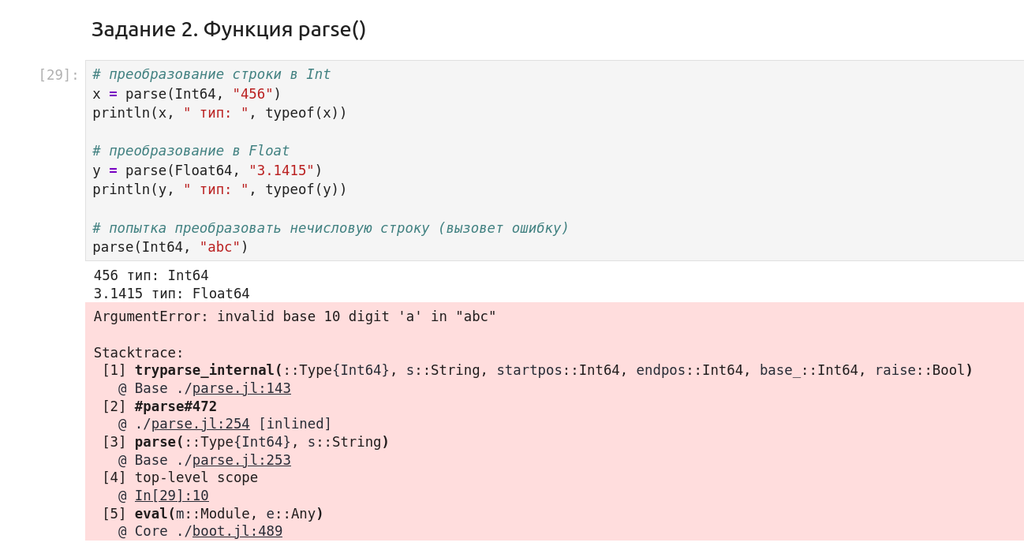

Рисунок 7: Задание 2. parse()

## Задание 3. Математические операции

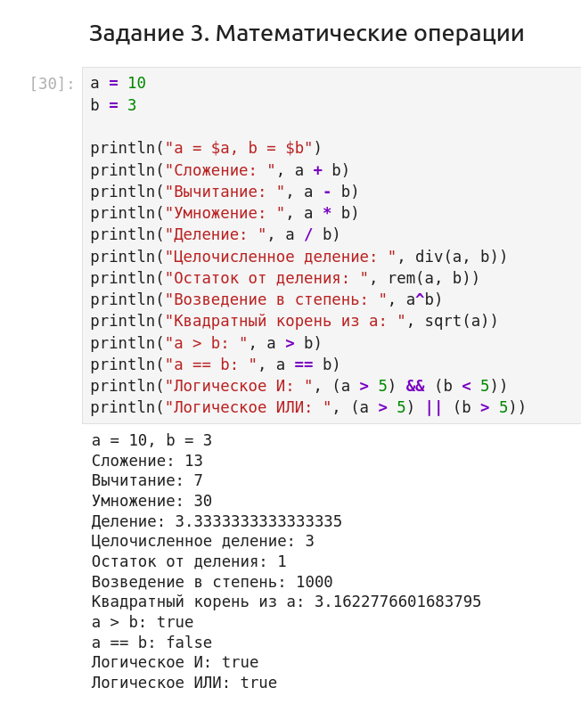

Рисунок 8: Задание 3. Математические операции

## Задание 4. Матрицы и векторы (часть 1)

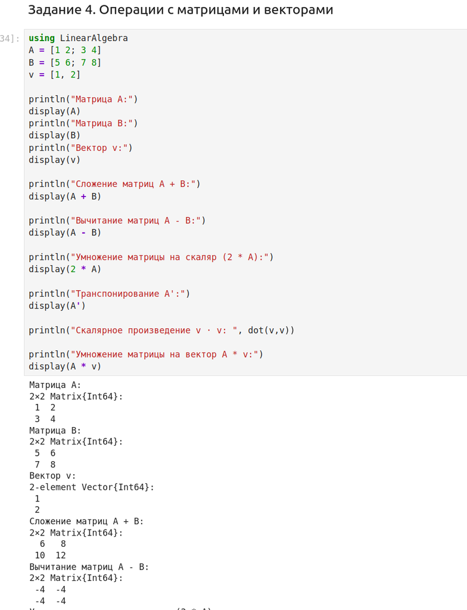

Рисунок 9: Задание 4. Матрицы и векторы, часть 1

## Задание 4. Матрицы и векторы (часть 2)

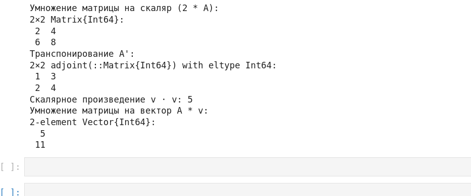

Рисунок 10: Задание 4. Матрицы и векторы, часть 2

# Результаты

## Основные результаты

- Установлены Julia (версия 1.12.5) и Jupyter Lab (версия 4.6.3)
- Установлен пакет IJulia для работы Julia в Jupyter
- В Jupyter Lab создан ноутбук с ядром Julia
- Успешно выполнены все примеры и задания
- Получены корректные результаты вычислений, включая работу с матрицами и векторами

# Заключение

## Главный вывод

В ходе лабораторной работы были выполнены все поставленные задачи. Цель работы достигнута. В дальнейшем планируется изучение более сложных пакетов Julia для статистического анализа и визуализации данных.